# Pipeline_record

### Preprocessing

#### 1. Split EPI_ISL_402124.fasta(reference) by covid proteins

–input /public/home/yudy01/Johnson_Johnson/GISAID/raw_data/ref_402124/EPI_ISL_402124.fasta

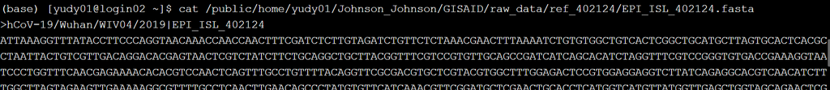

–output /public/home/yudy01/Johnson_Johnson/GISAID/raw_data/ref_402124/EPI_ISL_402124.each_protein.fasta

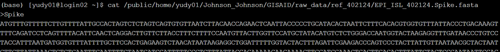

cd /public/home/yudy01/Johnson_Johnson/GISAID/raw_data/ref_402124/

perl scripts.2-get_gene_ref.single_gene.pl EPI_ISL_402124.fasta GeneRegion.tsv EPI_ISL_402124

#### 2. Transalate reference from nucleotides to amino acids

–input /public/home/yudy01/Johnson_Johnson/GISAID/raw_data/ref_402124/EPI_ISL_402124.each_protein.fasta

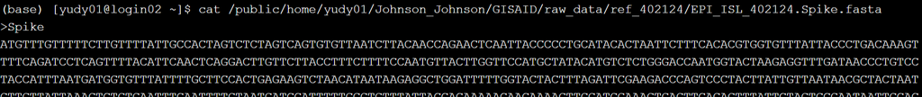

–output /public/home/yudy01/Johnson_Johnson/GISAID/raw_data/ref_402124/protein_EPI_ISL_402124.each_protein.fasta

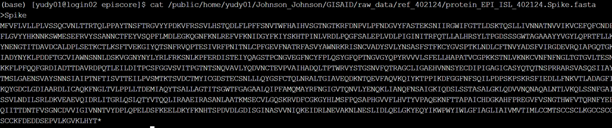

cd /public/home/yudy01/Johnson_Johnson/GISAID/raw_data/ref_402124/

python my_translate.py

#### 3. Get metadata of sequences

–input /public/home/yudy01/Johnson_Johnson/GISAID/raw_data/allprot0621/allprot0621.fasta

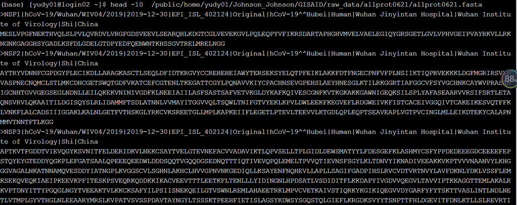

–output /public/home/yudy01/Johnson_Johnson/GISAID/meta_data.tsv

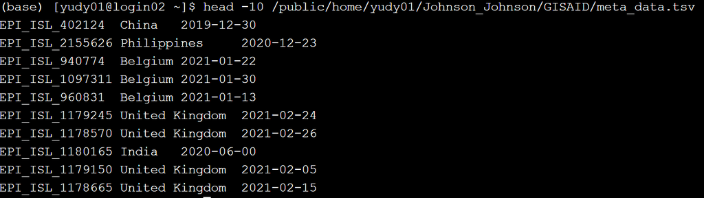

cd /public/home/yudy01/Johnson_Johnson/episcore/

python get_meta_data.py

4. Split protein sequences repertoire by covid proteins, and make batch of files to do alignment

–input /public/home/yudy01/Johnson_Johnson/GISAID/raw_data/allprot0621/allprot0621.fasta

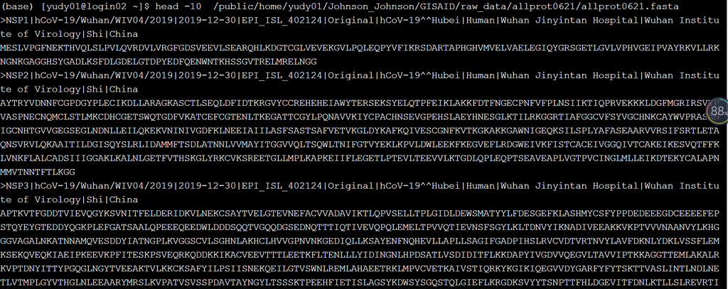

–output /public/home/yudy01/Johnson_Johnson/GISAID/raw_data/allprot0621/each_protein/each_protein_i.fasta

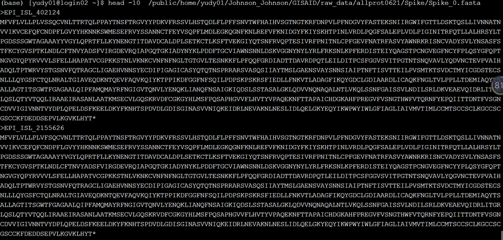

cd /public/home/yudy01/Johnson_Johnson/episcore/

python split_fasta_to_align.py

5. Align sequences by proteins with Enboss Needle

–input /public/home/yudy01/Johnson_Johnson/GISAID/raw_data/allprot0621/each_protein/each_protein_i.fasta,

/public/home/yudy01/Johnson_Johnson/GISAID/raw_data/ref_402124/protein_EPI_ISL_402124.each_protein.fasta

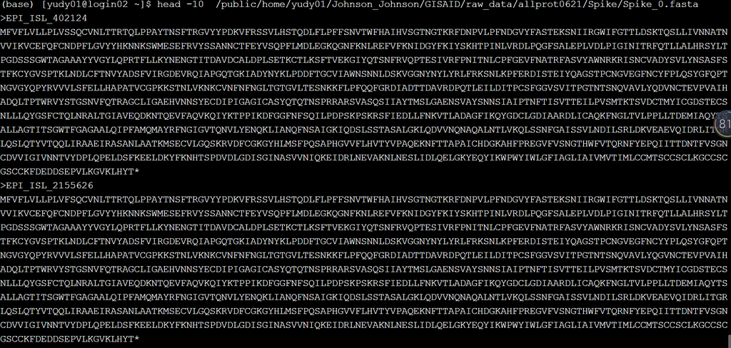

–output /public/home/yudy01/Johnson_Johnson/episcore/result/alignment/each_protein/needle_alignmenti.txt

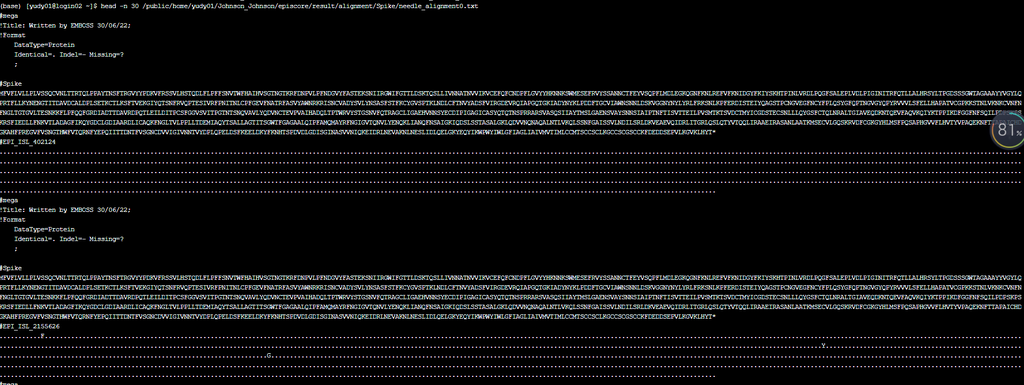

cd /public/home/yudy01/Johnson_Johnson/episcore/

python do_alignment1.py

python do_alignment2.py

python do_alignment3.py

6. Get varaints from result of alignment

–input /public/home/yudy01/Johnson_Johnson/episcore/result/alignment/each_protein/needle_alignmenti.txt

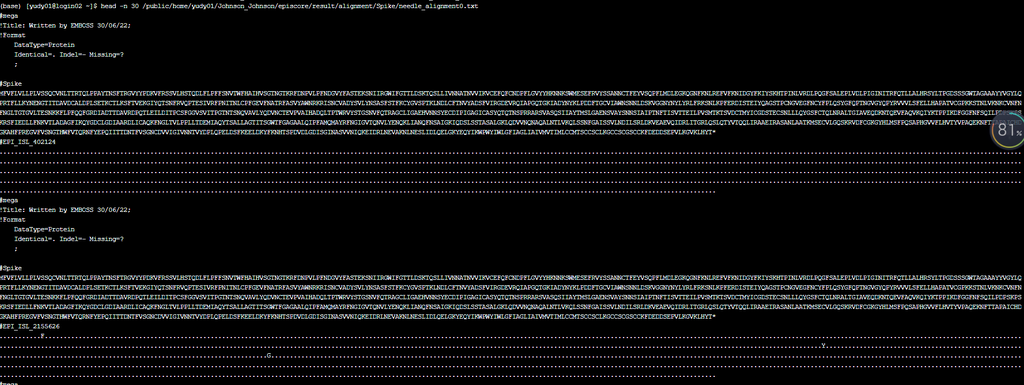

–output /public/home/yudy01/Johnson_Johnson/episcore/result/varaiants/each_protein/varaiants_needle_alignmenti.txt

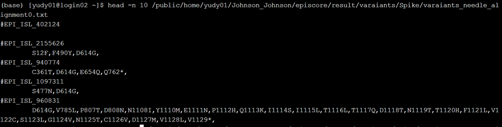

cd /public/home/yudy01/Johnson_Johnson/episcore/

python get_varaiants1.py

python get_varaiants2.py

python get_varaiants3.py